# VADeaths

coop711

## Tidy Data

깔끔한(tidy) 데이터를 만드는 방법에 대하여 알아본다. 사용되는 데이터는 `R`에 내장되어 있는 `VADeaths` 이다. 이 데이터의 구조는 5세 간격의 연령대를 행의 이름으로 하고, 장소(Rural, Urban)와 성별(Male, Female)의 조합을 열의 이름으로 갖는 행렬임을 알 수 있다.

```r
VADeaths
```

```
##       Rural Male Rural Female Urban Male Urban Female
## 50-54       11.7          8.7       15.4          8.4
## 55-59       18.1         11.7       24.3         13.6
## 60-64       26.9         20.3       37.0         19.3
## 65-69       41.0         30.9       54.6         35.1
## 70-74       66.0         54.3       71.1         50.0
```

```r
str(VADeaths)
```

```
##  num [1:5, 1:4] 11.7 18.1 26.9 41 66 8.7 11.7 20.3 30.9 54.3 ...
##  - attr(*, "dimnames")=List of 2
##   ..$ : chr [1:5] "50-54" "55-59" "60-64" "65-69" ...
##   ..$ : chr [1:4] "Rural Male" "Rural Female" "Urban Male" "Urban Female"
```

## `Base R` 의 도구 활용

왜 이 데이터가 깔끔하지(tidy) 않는지 생각해 보자. 데이터를 어떻게 표현해야 깔끔한 것인지 최종 결과물과 비교한다.

`c()`는 행렬 구조로 표현한 `VADeaths`를 기다란 하나의 벡터로 나타낸다. 이렇게 만든 한 줄의 벡터를 `Rates`에 옮겨 넣는다.

보통 `ordered()`가 아닌 `factor()`를 사용하는 경우가 많은데 연령이라는 변수의 특성을 감안하면 단순히 명목형이 아니고 엄연히 순서가 있기 때문에`ordered()`를 사용하는 것이 적절하다.

```r
Rates <- c(VADeaths)  ## 행렬를 한 줄의 벡터로 변환
N <- length(Rates) ## `Rates`의 크기를 `N`으로 저장.
Age <- ordered(rownames(VADeaths)) # 행 이름으로 주어진 글자 벡터, 연령대를 순서형 범주로 변환.
Age <- rep(ordered(rownames(VADeaths)), # 전체 관찰 수효 만큼 반복. `length.out = `의 용례에 유의.
           length.out = N)
Place <- gl(2, 10, N, # 농촌, 도시의 두 수준을 10번씩 반복하는 `factor` 설정
           labels = c("Rural", "Urban"))
Gender <- gl(2, 5, N, # 성별은 5번씩 반복
             labels = c("Male", "Female"))
data.frame(Age, Place, Gender, Rates) # 각 벡터를 데이터 프레임의 요소로 편성
```

```
##      Age Place Gender Rates
## 1  50-54 Rural   Male  11.7
## 2  55-59 Rural   Male  18.1
## 3  60-64 Rural   Male  26.9
## 4  65-69 Rural   Male  41.0
## 5  70-74 Rural   Male  66.0
## 6  50-54 Rural Female   8.7
## 7  55-59 Rural Female  11.7
## 8  60-64 Rural Female  20.3
## 9  65-69 Rural Female  30.9
## 10 70-74 Rural Female  54.3
## 11 50-54 Urban   Male  15.4
## 12 55-59 Urban   Male  24.3
## 13 60-64 Urban   Male  37.0
## 14 65-69 Urban   Male  54.6
## 15 70-74 Urban   Male  71.1
## 16 50-54 Urban Female   8.4
## 17 55-59 Urban Female  13.6
## 18 60-64 Urban Female  19.3
## 19 65-69 Urban Female  35.1
## 20 70-74 Urban Female  50.0
```

```r
VADeaths.df <- data.frame(Age, Place, Gender, Rates) # 데이터 프레임을 새로운 R 객체로 지정
VADeaths.df # 데이터 프레임 출력
```

```
##      Age Place Gender Rates
## 1  50-54 Rural   Male  11.7
## 2  55-59 Rural   Male  18.1
## 3  60-64 Rural   Male  26.9
## 4  65-69 Rural   Male  41.0
## 5  70-74 Rural   Male  66.0
## 6  50-54 Rural Female   8.7
## 7  55-59 Rural Female  11.7
## 8  60-64 Rural Female  20.3
## 9  65-69 Rural Female  30.9
## 10 70-74 Rural Female  54.3
## 11 50-54 Urban   Male  15.4
## 12 55-59 Urban   Male  24.3
## 13 60-64 Urban   Male  37.0
## 14 65-69 Urban   Male  54.6
## 15 70-74 Urban   Male  71.1
## 16 50-54 Urban Female   8.4
## 17 55-59 Urban Female  13.6
## 18 60-64 Urban Female  19.3
## 19 65-69 Urban Female  35.1
## 20 70-74 Urban Female  50.0
```

```r
str(VADeaths.df) # 데이터 프레임 구조 파악
```

```
## 'data.frame':    20 obs. of  4 variables:
##  $ Age   : Ord.factor w/ 5 levels "50-54"<"55-59"<..: 1 2 3 4 5 1 2 3 4 5 ...
##  $ Place : Factor w/ 2 levels "Rural","Urban": 1 1 1 1 1 1 1 1 1 1 ...
##  $ Gender: Factor w/ 2 levels "Male","Female": 1 1 1 1 1 2 2 2 2 2 ...
##  $ Rates : num  11.7 18.1 26.9 41 66 8.7 11.7 20.3 30.9 54.3 ...
```

`VADeaths`를 `table`구조로 변환하고, `as.data.frame`을 적용할 수도 있으나 `Place`와 `Gender`를 다시 분리하여야 함.

```r
as.data.frame(as.table(VADeaths))
```

```
##     Var1         Var2 Freq
## 1  50-54   Rural Male 11.7
## 2  55-59   Rural Male 18.1
## 3  60-64   Rural Male 26.9
## 4  65-69   Rural Male 41.0
## 5  70-74   Rural Male 66.0
## 6  50-54 Rural Female  8.7
## 7  55-59 Rural Female 11.7
## 8  60-64 Rural Female 20.3
## 9  65-69 Rural Female 30.9
## 10 70-74 Rural Female 54.3
## 11 50-54   Urban Male 15.4
## 12 55-59   Urban Male 24.3
## 13 60-64   Urban Male 37.0
## 14 65-69   Urban Male 54.6
## 15 70-74   Urban Male 71.1
## 16 50-54 Urban Female  8.4
## 17 55-59 Urban Female 13.6
## 18 60-64 Urban Female 19.3
## 19 65-69 Urban Female 35.1
## 20 70-74 Urban Female 50.0
```

혹은 한 번에

```r
as.data.frame.table(VADeaths)
```

```
##     Var1         Var2 Freq
## 1  50-54   Rural Male 11.7
## 2  55-59   Rural Male 18.1
## 3  60-64   Rural Male 26.9
## 4  65-69   Rural Male 41.0
## 5  70-74   Rural Male 66.0
## 6  50-54 Rural Female  8.7
## 7  55-59 Rural Female 11.7
## 8  60-64 Rural Female 20.3
## 9  65-69 Rural Female 30.9
## 10 70-74 Rural Female 54.3
## 11 50-54   Urban Male 15.4
## 12 55-59   Urban Male 24.3
## 13 60-64   Urban Male 37.0
## 14 65-69   Urban Male 54.6
## 15 70-74   Urban Male 71.1
## 16 50-54 Urban Female  8.4
## 17 55-59 Urban Female 13.6
## 18 60-64 Urban Female 19.3
## 19 65-69 Urban Female 35.1
## 20 70-74 Urban Female 50.0
```

## tidyverse를 이용한 방법

다음 코드를 차례대로 실행하면서 어떤 흐름이 잡히는 지 살펴보시오.

경고문의 `Conflicts ...`이하는 `R Base`에 있는 `filter()`나 `lag()`함수를 사용하려면 구체적으로 `stats::filter()` 나 `stats::lag()`라고 하여야 한다는 것을 의미한다.

```r
library(tidyverse) # `tidyverse`를 검색 경로에 올려 놓음. 함께 불러들이는 패키지들과 경고문에 유의.
VADeaths.tbl <- VADeaths %>% # 최종 결과물을 `tibble` 형식으로 지정.
  as_tibble() %>% # 행렬 구조를 `tibble`구조로 변환. `tbl_df()`는 더 이상 사용되지 않음.
  mutate(Age = row.names(VADeaths)) %>% # 행 이름으로 주어진 연령대를 글자벡터로 생성
  gather(key = Place_Gender, # `Age`를 제외한 나머지 뱐수를 `key, value`쌍으로 정리하면서 새로운 변수명 부여.
         value = Rates,
         -Age) %>%
  separate(Place_Gender, c("Place", "Gender"), # `Place_Gender`를 `Place`와 `Gender`로 분리.
           sep = " ") %>%
  mutate(Age = ordered(Age), # `Age`, `Place`, `Gender`를 순서형 범주와 명목형 범주로 변환
         Place = factor(Place),
         Gender = factor(Gender,  # `Gender`에서 `level = `를 설정하지 않으면 알파벳 순에 따라 수준이 정해짐.
                         levels = c("Male", "Female"))) # 즉, `Female`이 1, `Male`이 2가 됨.
VADeaths.tbl # `tibble` 형식으로 출력
```

```
## # A tibble: 20 x 4
##      Age  Place Gender Rates
##    <ord> <fctr> <fctr> <dbl>
##  1 50-54  Rural   Male  11.7
##  2 55-59  Rural   Male  18.1
##  3 60-64  Rural   Male  26.9
##  4 65-69  Rural   Male  41.0
##  5 70-74  Rural   Male  66.0
##  6 50-54  Rural Female   8.7
##  7 55-59  Rural Female  11.7
##  8 60-64  Rural Female  20.3
##  9 65-69  Rural Female  30.9
## 10 70-74  Rural Female  54.3
## 11 50-54  Urban   Male  15.4
## 12 55-59  Urban   Male  24.3
## 13 60-64  Urban   Male  37.0
## 14 65-69  Urban   Male  54.6
## 15 70-74  Urban   Male  71.1
## 16 50-54  Urban Female   8.4
## 17 55-59  Urban Female  13.6
## 18 60-64  Urban Female  19.3
## 19 65-69  Urban Female  35.1
## 20 70-74  Urban Female  50.0
```

```r
str(VADeaths.tbl) # 구조 파악.
```

```
## Classes 'tbl_df', 'tbl' and 'data.frame':    20 obs. of  4 variables:
##  $ Age   : Ord.factor w/ 5 levels "50-54"<"55-59"<..: 1 2 3 4 5 1 2 3 4 5 ...
##  $ Place : Factor w/ 2 levels "Rural","Urban": 1 1 1 1 1 1 1 1 1 1 ...
##  $ Gender: Factor w/ 2 levels "Male","Female": 1 1 1 1 1 2 2 2 2 2 ...
##  $ Rates : num  11.7 18.1 26.9 41 66 8.7 11.7 20.3 30.9 54.3 ...
```

이 과정을 순서대로 살펴보면, 먼저 행렬 구조를 `tibble`형식으로 변환하고,

```r
VADeaths %>%
  as_tibble()
```

```
## # A tibble: 5 x 4
##   `Rural Male` `Rural Female` `Urban Male` `Urban Female`
##          <dbl>          <dbl>        <dbl>          <dbl>
## 1         11.7            8.7         15.4            8.4
## 2         18.1           11.7         24.3           13.6
## 3         26.9           20.3         37.0           19.3
## 4         41.0           30.9         54.6           35.1
## 5         66.0           54.3         71.1           50.0
```

`Age` 변수 생성

```r
VADeaths %>%
  as_tibble() %>%
  mutate(Age = rownames(VADeaths))
```

```
## # A tibble: 5 x 5
##   `Rural Male` `Rural Female` `Urban Male` `Urban Female`   Age
##          <dbl>          <dbl>        <dbl>          <dbl> <chr>
## 1         11.7            8.7         15.4            8.4 50-54
## 2         18.1           11.7         24.3           13.6 55-59
## 3         26.9           20.3         37.0           19.3 60-64
## 4         41.0           30.9         54.6           35.1 65-69
## 5         66.0           54.3         71.1           50.0 70-74
```

`Age` 를 제외한 변수를 `key, value` 쌍으로 정리하면서 새로운 변수명 부여, `Age`의 새로운 위치에 유의

```r
VADeaths %>%
  as_tibble() %>%
  mutate(Age = rownames(VADeaths)) %>%
  gather(key = Place_Gender,
         value = Rates,
         -Age)
```

```
## # A tibble: 20 x 3
##      Age Place_Gender Rates
##    <chr>        <chr> <dbl>
##  1 50-54   Rural Male  11.7
##  2 55-59   Rural Male  18.1
##  3 60-64   Rural Male  26.9
##  4 65-69   Rural Male  41.0
##  5 70-74   Rural Male  66.0
##  6 50-54 Rural Female   8.7
##  7 55-59 Rural Female  11.7
##  8 60-64 Rural Female  20.3
##  9 65-69 Rural Female  30.9
## 10 70-74 Rural Female  54.3
## 11 50-54   Urban Male  15.4
## 12 55-59   Urban Male  24.3
## 13 60-64   Urban Male  37.0
## 14 65-69   Urban Male  54.6
## 15 70-74   Urban Male  71.1
## 16 50-54 Urban Female   8.4
## 17 55-59 Urban Female  13.6
## 18 60-64 Urban Female  19.3
## 19 65-69 Urban Female  35.1
## 20 70-74 Urban Female  50.0
```

`Place_Gender`를 `Place`와 `Gender`로 분리. `sep =`의 사용 방법에 유의.

```r
VADeaths %>%
  as_tibble() %>%
  mutate(Age = rownames(VADeaths)) %>%
  gather(key = Place_Gender,
         value = Rates,
         -Age) %>%
  separate(Place_Gender, c("Place", "Gender"),
           sep = " ")
```

```
## # A tibble: 20 x 4
##      Age Place Gender Rates
##  * <chr> <chr>  <chr> <dbl>
##  1 50-54 Rural   Male  11.7
##  2 55-59 Rural   Male  18.1
##  3 60-64 Rural   Male  26.9
##  4 65-69 Rural   Male  41.0
##  5 70-74 Rural   Male  66.0
##  6 50-54 Rural Female   8.7
##  7 55-59 Rural Female  11.7
##  8 60-64 Rural Female  20.3
##  9 65-69 Rural Female  30.9
## 10 70-74 Rural Female  54.3
## 11 50-54 Urban   Male  15.4
## 12 55-59 Urban   Male  24.3
## 13 60-64 Urban   Male  37.0
## 14 65-69 Urban   Male  54.6
## 15 70-74 Urban   Male  71.1
## 16 50-54 Urban Female   8.4
## 17 55-59 Urban Female  13.6
## 18 60-64 Urban Female  19.3
## 19 65-69 Urban Female  35.1
## 20 70-74 Urban Female  50.0
```

각 구성요소를 특성에 맞게 변환. `Gender`의 경우 `levels =` 를 설정하는 이유에 대하여 생각해 볼 것.

```r
VADeaths %>%
  as_tibble() %>%
  mutate(Age = rownames(VADeaths)) %>%
  gather(key = Place_Gender,
         value = Rates,
         -Age) %>%
  separate(Place_Gender, c("Place", "Gender"),
           sep = " ") %>%
  mutate(Age = ordered(Age),
         Place = factor(Place),
         Gender = factor(Gender,
                         levels = c("Male", "Female")))
```

```
## # A tibble: 20 x 4
##      Age  Place Gender Rates
##    <ord> <fctr> <fctr> <dbl>
##  1 50-54  Rural   Male  11.7
##  2 55-59  Rural   Male  18.1
##  3 60-64  Rural   Male  26.9
##  4 65-69  Rural   Male  41.0
##  5 70-74  Rural   Male  66.0
##  6 50-54  Rural Female   8.7
##  7 55-59  Rural Female  11.7
##  8 60-64  Rural Female  20.3
##  9 65-69  Rural Female  30.9
## 10 70-74  Rural Female  54.3
## 11 50-54  Urban   Male  15.4
## 12 55-59  Urban   Male  24.3
## 13 60-64  Urban   Male  37.0
## 14 65-69  Urban   Male  54.6
## 15 70-74  Urban   Male  71.1
## 16 50-54  Urban Female   8.4
## 17 55-59  Urban Female  13.6
## 18 60-64  Urban Female  19.3
## 19 65-69  Urban Female  35.1
## 20 70-74  Urban Female  50.0
```

## Plots

이 데이터 프레임을 시각적으로 `ggplot()`을 이용하여 표현하는 방법에 대하여 생각해 보자. 먼저 기본 함수들을 이용하여 생성한 `VADeaths.df`를 이용하여 그려보면, `data = VADeaths.df`로 설정하고, `aes()`의 `x =` 에는 장소(`Place`)와 성별(`Gender`)의 조합인 농촌남성(`Rural.Male`), 도시남성(`Urban.Male`), 농촌여성(`Rural.Female`), 도시여성(`Urban.Female`)을 `interaction(Place, Gender)`로 나타낸다. `y =`에는 사망률(`Rates`)을, 각 연령대(`Age`)를 막대의 색깔(`fill =`)로 구분한다.

막대그래프로 표현하기 위하여 `geom_bar()`를 사용하였는데, 가장 간단한 형식으로 나타내었다. 추가 정보나 보다 세부적인 표현은 다음에 다루기로 한다.

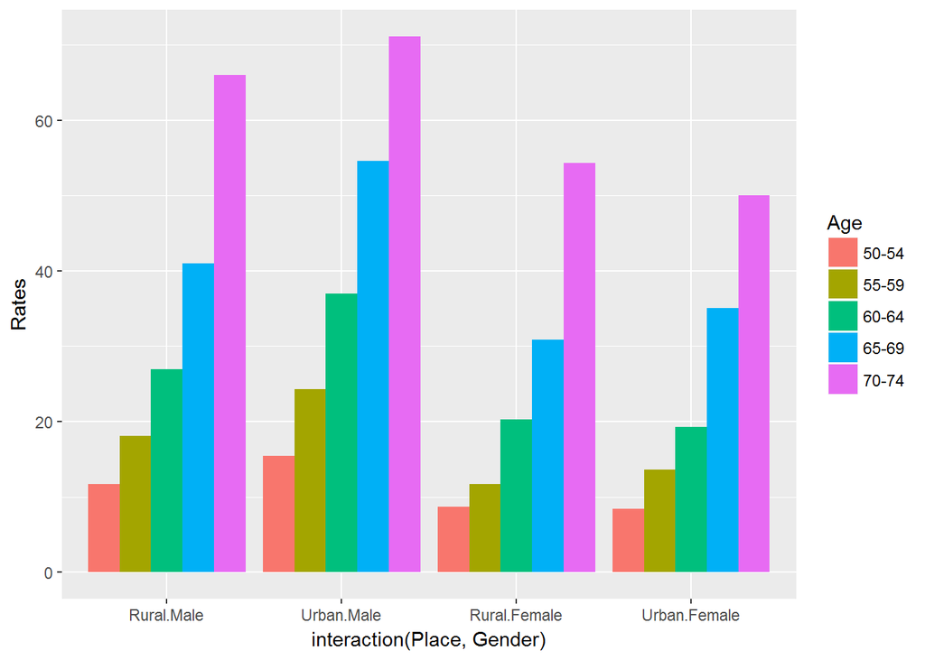

```r
ggplot(data = VADeaths.df,
              mapping = aes(x = interaction(Place, Gender),
                            y = Rates,
                            fill = Age)) +
geom_bar(stat = "identity",
         position = position_dodge())
```

동일한 내용을 `VADeaths.tbl`로 그리면,

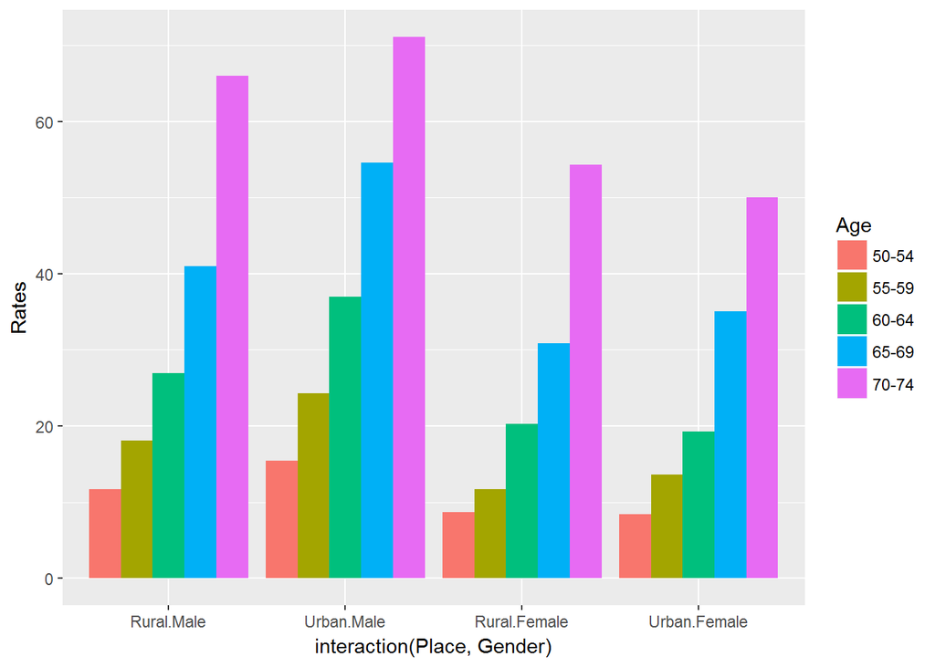

```r
ggplot(data = VADeaths.tbl,
              mapping = aes(x = interaction(Place, Gender),
                            y = Rates,
                            fill = Age)) +
geom_bar(stat = "identity",
         position = position_dodge())
```

막대의 색깔을 Sequential 팔렛뜨 계열(`scale_fill_brewer` 도움말 참조)의 색깔 중 연령대의 변화에 맞도록 조정하면,

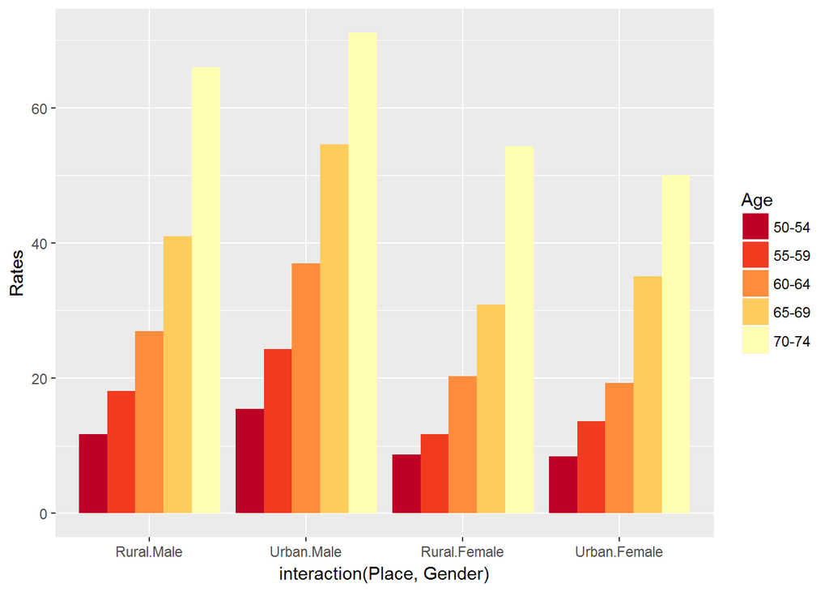

```r
ggplot(data = VADeaths.tbl,
              mapping = aes(x = interaction(Place, Gender),
                            y = Rates,
                            fill = Age)) +
geom_bar(stat = "identity",
         position = position_dodge()) +
scale_fill_brewer(palette = "YlOrRd",
                  direction = -1)
```

`facet_grid`를 이용하여 패널로 구분하여 나타내면,

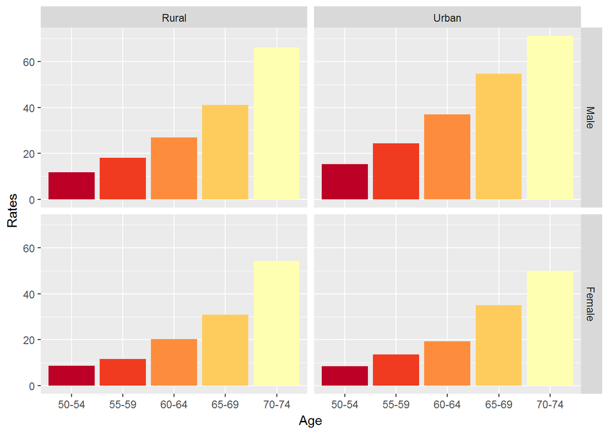

```r
ggplot(data = VADeaths.tbl,
              mapping = aes(x = Age,
                            y = Rates,
                            fill = Age)) +
geom_bar(stat = "identity",
         position = position_dodge()) +
scale_fill_brewer(guide = FALSE,
                  palette = "YlOrRd",
                  direction = -1) +
facet_grid(Gender ~ Place)
```